# Marthas Vineyard SET report

Produced for Martha’s Vineyard Commission

Author

Affiliation

Laura Feher

NPS NCBN I&M Network

Published

September 25, 2025

**NOTE:** The SET-MH approach has been widely used for documenting and interpreting trends in surface elevation dynamics over time and assessing wetland vulnerability to sea-level rise. Thus, the methods used here for the analyses of SET and sea-level rise data follow the standard conventions outlined in the following peer reviewed literature: Cahoon, Lynch, Hensel, et al. (2002); Cahoon, Lynch, Perez, et al. (2002); Cahoon et al. (2006); Cahoon (2024); Callaway, Cahoon, and Lynch (2013); Lynch, Hensel, and Cahoon (2015).

## Methods: Data Analyses

Prior to data analyses, we subtracted the elevation reading of each pin on each sampling date from its initial value to determine cumulative elevation change (Lynch, Hensel, and Cahoon 2015). The pin-level elevation readings for each measurement date were then averaged across each of the four bearings on each benchmark, then the bearing-level values were averaged to the plot level, and finally the plot-level values were averaged to the site level. To estimate the rate of marsh surface elevation change at each site, we used a simple linear regression model where the independent variable was the time since the first measurement and the dependent variable was site-level cumulative marsh surface elevation change as outlined in Feher et al. (2024) and Russell et al. (2022).

## Methods: Relative Sea-Level Rise

For the long-term rate of relative sea-level rise (RSLR; also known as local sea-level rise), we obtained the rate published by NOAA for the nearby tide gauge at Woods Hole, MA (NOAA 2025) for the entire period of record from 1932 to 2024. We estimated a recent rate of RSLR using a linear regression applied to the monthly mean sea-level data with the average seasonal cycle removed by subsetting the data from the Woods Hole gauge for the most recent tidal epoch (2001 -2019).

We estimated future projected RSLR rates using the five alternative SLR scenarios produced by Sweet et al. (2022) for the 5th National Climate Assessment. The Low, Intermediate-Low, Intermediate, Intermediate-High, and High SLR scenarios correspond respectively to global mean sea level increases of 0.3 m, 0.5 m, 1.0 m, 1.5 m, and 2.0 m by 2100. To approximate the RSLR rate by 2100 under each of the five scenarios, we used the data provided by Sweet et al. (2022) to estimate future RSLR rates for the 2090-2100 decade from the Woods Hole RSLR projections.

## Results: Rates of Marsh Surface Elevation Change

The rate of marsh surface elevation change at Aquinnah was 5.09 ± 1.15 mm/yr (*r*<sup>2</sup> = 0.76, *p* < 0.01 ) for the period between 2019 to 2025 (Fig. 1). The rate of marsh surface elevation change at Felix Neck was 3.73 ± 0.35mm/yr (*r*<sup>2</sup> = 0.93, *p* < 0.001 ) for the period between 2016 to 2025 (Fig 2).

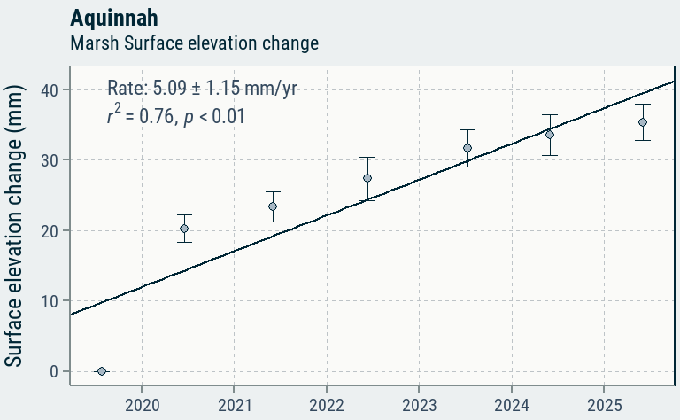

Figure 1. Marsh surface elevation change at Aquinnah between 2019-2025.

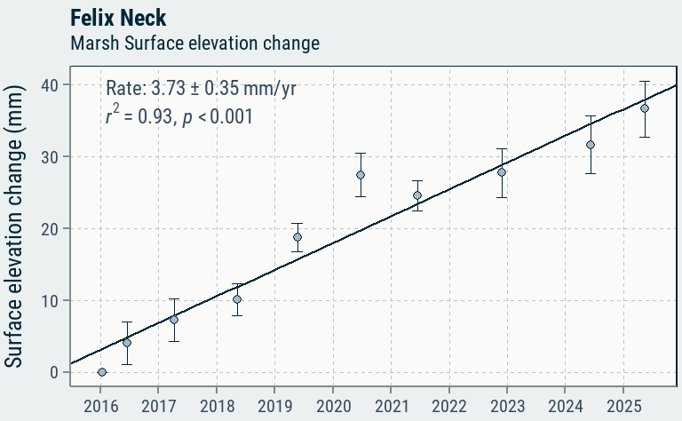

Figure 2. Marsh surface elevation change at Felix Neck between 2016-2025.

## Results: Marsh Surface Elevation Change vs. Long-term & Recent SLR

The long-term rate of RSLR at the nearby Woods Hole tide gauge was 3.13 ± 0.17 mm/yr, whereas the recent rate of RSLR was 5.66 ± 0.54 mm/yr. Accordingly, while the marshes at both Aquinnah and Felix Neck have been building surface elevation at a rate close to or slightly above the long-term rate of SLR, neither marsh is keeping pace with the accelerated recent rate of sea-level rise in the region (Fig 3/Fig 4 and Fig 5/Fig 6).

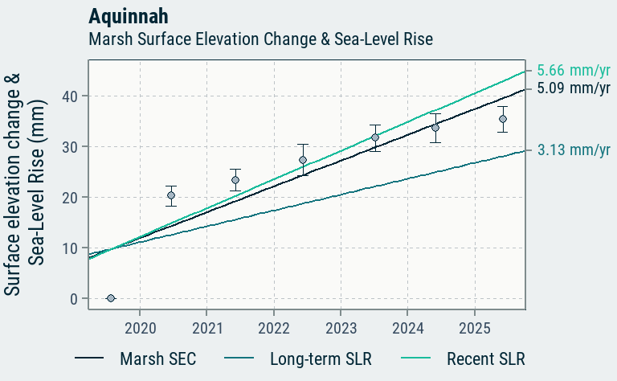

Figure 3. (Opt. A) Marsh surface elevation change at Aquinnah as compared to long-term and recent rates of SLR. Values to the right of the colored lines represent the rate of marsh surface elevation change at Aquinnah and the long-term and recent rates of SLR from the Woods Hole gauge.

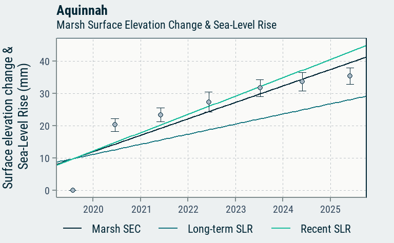

Figure 4. (Opt. B) Marsh surface elevation change at Aquinnah as compared to long-term and recent rates of SLR. The rate of surface elevation change at Aquinnah between 2019-2025 was 5.09 ± 1.15 mm/yr (*r<sup>2</sup>* = 0.76, *p*< 0.01). Using the data published by NOAA for the nearby gauge at Woods Hole, MA, the long-term rate of SLR was 3.13 ± 0.17 mm/yr and the recent rate of SLR was 5.66 ± 0.54 mm/yr.

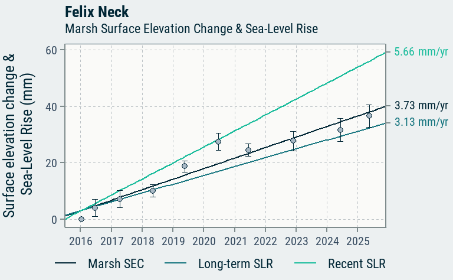

Figure 5. (Opt. A) Marsh surface elevation change at Felix Neck as compared to long-term and recent rates of SLR. Values to the right of the colored lines represent the rate of marsh surface elevation change at Felix Neck and the long-term and recent rates of SLR from the Woods Hole gauge.

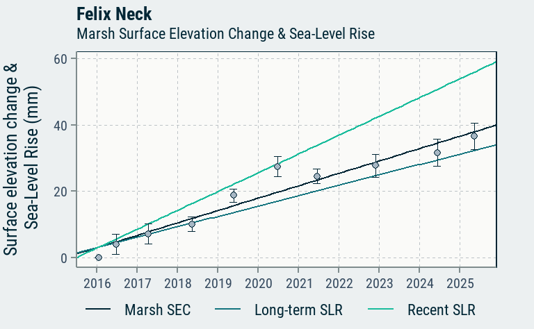

Figure 6. (Opt. B) Marsh surface elevation change at Felix Neck as compared to long-term and recent rates of SLR. The rate of surface elevation change at Felix Neck between 2016-2025 was 3.73 ± 0.35 mm/yr (*r<sup>2</sup>* = 0.93, *p*< 0.001). Using the data published by NOAA for the nearby gauge at Woods Hole, MA, the long-term rate of SLR was 3.13 ± 0.17 mm/yr and the recent rate of SLR was 5.66 ± 0.54 mm/yr.

## Results: Marsh Surface Elevation Change vs. Future SLR

Future predicted rates of RSLR for the Woods Hole gauge were 4, 7, 21, 28, and 35 mm/yr for the low, intermediate-low, intermediate, intermediate-high, and high sea-level rise scenarios, respectively, for the decade between 2090 to 2100. Although the marsh at Aquinnah has been building surface elevation at a rate close to or slightly above the rate of SLR predicted by the future low scenario (5.09 ± 1.15 mm/yr), the rate of marsh surface elevation change at the site was lower than any of the other future predicted SLR scenarios. Thus, its unlikely that the marsh at Aquinnah will be able to keep pace with future predicted rates of sea-level rise that are any greater than the lowest SLR scenario (Fig 7/Fig 8). Similarly, the rate of marsh surface elevation change at Felix Neck was lower than all of the future predicted SLR scenarios (3.73 ± 0.35 mm/yr), making it unlikely that this marsh will be able to keep pace with any future acceleration in the rate of SLR (Fig 9/Fig 10).

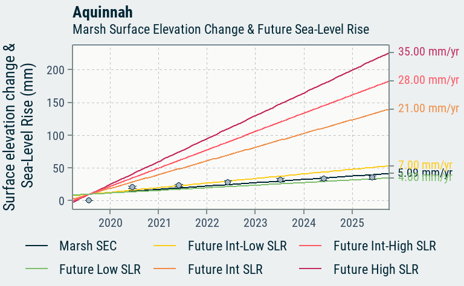

Figure 7. (Opt. A) Marsh surface elevation change at Aquinnah as compared to future predicted rates of SLR. Values to the right of the colored lines represent the rate of marsh surface elevation change at Aquinnah and the rates of sea-level rise predicted by each of the future SLR scenarios for the nearby gauge at Woods Hole, MA.

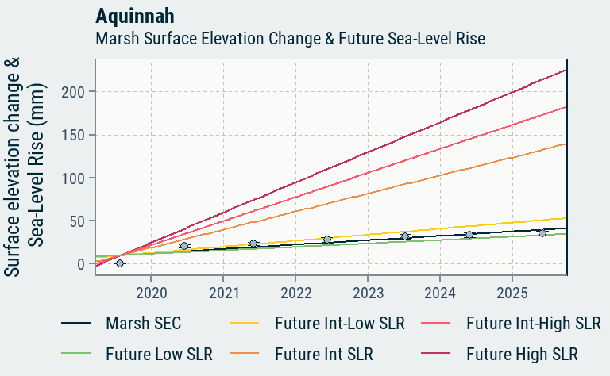

Figure 8. (Opt. B) Marsh surface elevation change at Aquinnah as compared to future predicted rates of SLR. The rate of surface elevation change at Aquinnah between 2019-2025 was 5.09 ± 1.15 mm/yr (*r<sup>2</sup>* = 0.76, *p*< 0.01). Using the data published by NOAA for the nearby gauge at Woods Hole, MA, future predicted rates of SLR were 4, 7, 21, 28, and 35 mm/yr for the low, intermediate-low, intermediate, intermediate-high, and high SLR scenarios, respectively.

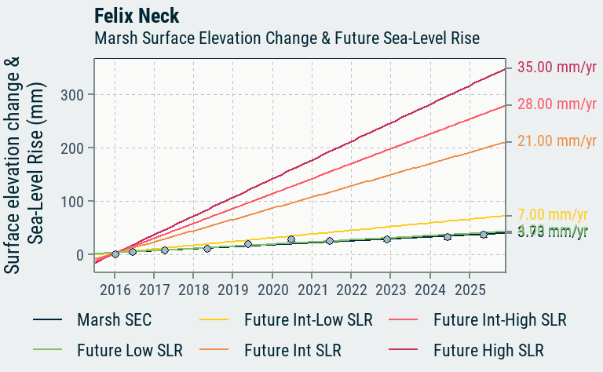

Figure 9. (Opt. A) Marsh surface elevation change at Felix Neck as compared to future predicted rates of SLR. Values to the right of the colored lines represent the rate of marsh surface elevation change at Felix Neck and the rates of sea-level rise predicted by each of the future SLR scenarios for the nearby gauge at Woods Hole, MA.

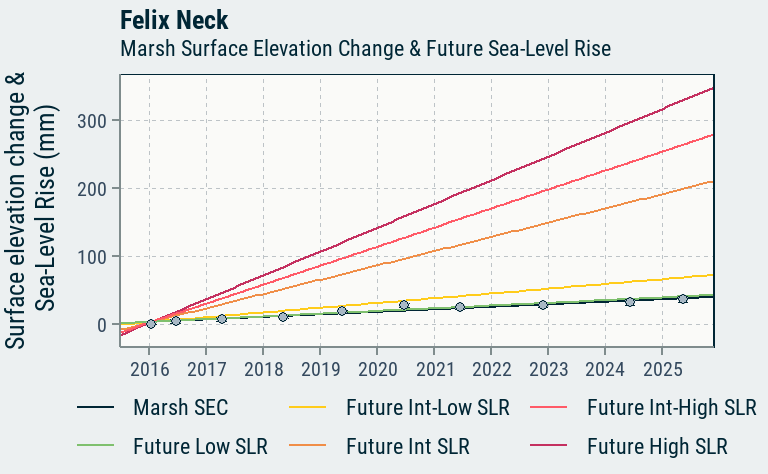

Figure 10. (Opt. B) Marsh surface elevation change at Felix Neck as compared to future predicted rates of SLR. The rate of surface elevation change at Felix Neck between 2016-2025 was 3.73 ± 0.35 mm/yr (*r<sup>2</sup>* = 0.93, *p*< 0.001). Using the data published by NOAA for the nearby gauge at Woods Hole, MA, future predicted rates of SLR were 4, 7, 21, 28, and 35 mm/yr for the low, intermediate-low, intermediate, intermediate-high, and high SLR scenarios, respectively.

## References

Cahoon, D. R. 2024. “Measuring and Interpreting the Surface and Shallow Subsurface Process Influences on Coastal Wetland Elevation: A Review.” *Estuaries and Coasts* 47 (7): 1708–34.

Cahoon, D. R., P. F. Hensel, T. Spencer, D. J. Reed, K. L. McKee, and N. Saintilan. 2006. “Coastal Wetland Vulnerability to Relative Sea-Level Rise: Wetland Elevation Trends and Process Controls.” In *Wetlands and Natural Resource Management*, edited by J. T. A. Verhoeven, B. Beltman, R. Bobbink, and D. F. Whigham, 271–92. Berlin: Springer.

Cahoon, D. R., J. C. Lynch, P. Hensel, R. Boumans, B. C. Perez, B. Segura, and J. W. Day Jr. 2002. “High-Precision Measurements of Wetland Sediment Elevation: I. Recent Improvements to the Sedimentation-Erosion Table.” *Journal of Sedimentary Research* 72 (5): 730–33.

Cahoon, D. R., J. C. Lynch, B. C. Perez, B. Segura, R. D. Holland, C. Stelly, G. Stephenson, and P. Hensel. 2002. “High-Precision Measurements of Wetland Sediment Elevation: II. The Rod Surface Elevation Table.” *Journal of Sedimentary Research* 72 (5).

Callaway, J. C., D. R. Cahoon, and J. C. Lynch. 2013. “The Surface Elevation Table-Marker Horizon Method for Measuring Wetland Accretion and Elevation Dynamics.” In *Methods in Biogeochemistry of Wetlands*, edited by R. D. DeLaune, K. Reddy, C. Richardson, and J. P. Megonigal, 901–17. Madison, WI: Soil Science Society of America.

Feher, L. C., M. J. Osland, D. J. Johnson, J. B. Grace, G. R. Guntenspergen, D. R. Stewart, C. Coronado-Molina, and F. H. Sklar. 2024. “Nonlinear Patterns of Surface Elevation Change in Coastal Wetlands: The Value of Generalized Additive Models for Quantifying Rates of Change.” *Estuaries and Coasts* 47 (7): 1893–1902.

Lynch, J. C., Hensel P., and D. H. Cahoon. 2015. “The Surface Elevation Table and Marker Horizon Technique: A Protocol for Monitoring Wetland Elevation Dynamics, Natural Resource Report NPS/NCBN/NRR-2015/1078.” Fort Collins, CO: National Park Service; https://irma.nps.gov/DataStore/Reference/Profile/2225005.

NOAA. 2025. “NOAA Tides and Currents: Relative Sea Level Trend 8447930 Woods Hole, Massachusetts.” https://tidesandcurrents.noaa.gov/sltrends/sltrends_station.shtml?id=8447930.

Russell, B. T., K. A. Cressman, J. P. Schmit, S. Shull, J. M. Rybczyk, and D. L. Frost. 2022. “How Should Surface Elevation Table Data Be Analyzed? A Comparison of Several Commonly Used Analysis Methods and One Newly Proposed Approach.” *Environmental and Ecological Statistics* 29 (2): 359–91.

Sweet, W. V., B. D. Hamlington, R. E. Kopp, C. P. Weaver, P. L. Barnard, W. Brooks D. Bekaert, M. Craghan, et al. 2022. “Global and Regional Sea-Level Rise Scenarios for the United States: Updated Mean Projections and Extreme Water Level Probabilities Along u.s. Coastlines, NOAA Technical Report NOS 01.” Silver Spring, MD: National Oceanic; Atmospheric Administration; https://oceanservice.noaa.gov/hazards/sealevelrise/noaa-nos-techrpt01-global-regional-SLR-scenarios-US.pdf.